# Project 1

*Water Cycle Climatology for a Watershed*

By: Gregory Ewing

Date: 2/1/2019

**Part A) Pick a stream gauge.**

**Stream Gage**: USGS 04045500 Tahquamenon River Near Paradise, MI

[Summary Data Here](https://waterdata.usgs.gov/nwis/inventory/?site_no=04045500&agency_cd=USGS)

**Description**

- Latitude 46°34'30", Longitude 85°16'10" NAD27
- Luce County, Michigan, Hydrologic Unit 04020202
- Drainage area: 790 square miles (22,023,620,000 ft^2)
- Datum of gage: 698.03 feet above NGVD29.

Remarks from the latest Water-Year-Summary Report, 2017, make no mention to regulated flows of any kind. The earliest report availabe, 2006, states that "records good for estimated daily discharges, which are fair. Several measurements of water temperature were made during the year. Gage-height telemeter at station. Remarks are included verbatim in screenshots form below.

**2006 Remarks:**

[figure not shown]

**2017 Remarks:**

[figure not shown]

**Part B) Create a table showing the average monthly discharge for 1981 to 2010. Find the 30-year average for your table.**

```python
import pandas as pd
import numpy as np
import datetime as dt
import matplotlib.pyplot as plt
```

```python
Area_mi2 = 790
Area_ft2 = Area_mi2 * 27878000
date_range = (dt.datetime(year=1980,month=12,day=29), dt.datetime(year=2010,month=12,day=29))
```

```python
data = pd.read_csv(
    'TahquamenonRiver_04045500_MonthlyStatistics.txt',
    sep = '\t',
    names = ['Agency','Site Number','Parameter Code','Timeseries ID','Year','Month','Mean Value [ cfs ]'],
    skiprows = 37,
    usecols = [4,5,6]
)

# Set Years and Months to Type String
data.Year = data.Year.astype(str)
data.Month = data.Month.astype(str)

# Join the strings with a -01- for the day.
a = data.Month + '-01-'+ data.Year

# Convert to a datatime format
data['Date'] = pd.to_datetime(a)

# Add column for days in the month... includes leap years for February
data['DaysInMonth'] = data.Date.dt.daysinmonth

# Revert Month & Year back to type int
data.Year = data.Year.astype(str)
data.Month = data.Month.astype(str)

# Select for data in Normal Range
Data_Normal = data[data['Date']>date_range[0]]
Data_Normal =  Data_Normal[Data_Normal['Date']<date_range[1]]
```

**CFS to Total Volume**

Have flow in $\frac{ft^3}{s}$, want $\frac{ft^3}{month}$.

To accomplish do the following: $$\frac{ft^3}{s} * \frac{60 s}{1 min} * \frac{60 min}{1 hr} * \frac{24 hr}{1 day} * \frac{Days In Month}{1 month} = \big[\frac{ft^3}{month}\big] $$

```python
# Compute Monthly Discharges in Cubic Feet
Data_Normal['Volume_ft3'] = Data_Normal['Mean Value [ cfs ]'] * Data_Normal['DaysInMonth'] * 60 * 60 * 24
```

**Total Volume to Depth in Inches**

To calculate this volume in inches on the watershed:

$$ \frac{ft^3}{month} * \frac{1}{Watershed Area} * \frac{12 in}{1 ft} = \big[\frac{in}{month}\big] $$

```python
# Compute Monthly Discharge in Inches
Data_Normal['Volume [ in ]'] = Data_Normal['Volume_ft3'] / Area_ft2 * 12
```

**Prepare Table**

```python
Months = Data_Normal.drop(columns=['DaysInMonth','Volume_ft3']).groupby('Month')
Months = Months.mean()

# Need to reorder the table by month now
Month_str = Months.reindex(index=['January','October','November','December','February','March','April','May','June','July','August','September'])
for i in range(0,12):
    Month_str.iloc[i] = Months.iloc[i]
Month_str = Month_str.reindex(['January','February','March','April','May','June','July','August','September','October','November','December'])
Month_str
```

| Month | Mean Value [ cfs ] | Volume [ in ] |
| --- | --- | --- |
| January | 548.453333 | 0.800401 |
| February | 495.476667 | 0.659085 |
| March | 855.493333 | 1.248489 |
| April | 2636.523333 | 3.723567 |
| May | 1251.040000 | 1.825741 |
| June | 579.516667 | 0.818452 |
| July | 419.986667 | 0.612920 |
| August | 377.286667 | 0.550604 |
| September | 494.403333 | 0.698247 |
| October | 859.063333 | 1.253699 |
| November | 992.780000 | 1.402105 |
| December | 783.790000 | 1.143846 |

**Part C) Create a table showing the average monthly precipitation (in inches) for the watershed.**

```python
months = ['January','February','March','April','May','June','July','August','September','October','November','December']
precip = [3.12, 1.91, 2.16, 2.34, 2.74, 2.93, 3.04, 3.41, 3.72, 4.10, 3.27, 3.44]

Precip_Normal = dict(zip(months,precip))
Precip_Normal = pd.DataFrame.from_dict(Precip_Normal, orient='index', )
Precip_Normal = Precip_Normal.rename(index=str, columns={0:'Precip Normals [ in ]'})
```

**Part D) Plot the average monthly precipitation (in inches) and the average monthly discharge (in inches) versus month.**

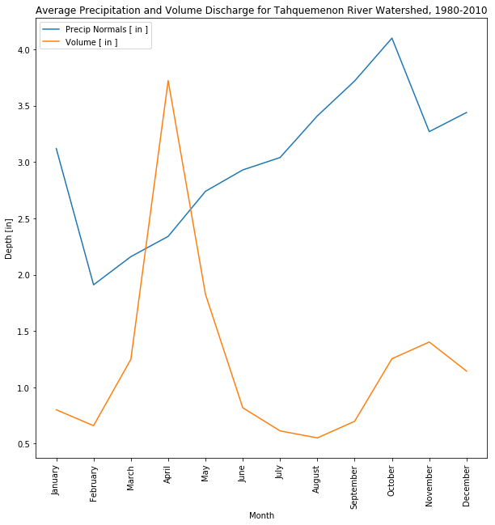

```python
fig, ax = plt.subplots(figsize=(10,10))

Precip_Normal.plot(ax=ax,xticks=np.arange(12),legend=True)
Month_str['Volume [ in ]'].plot(ax=ax,xticks=np.arange(12),legend=True)

plt.xticks(rotation='vertical')
plt.ylabel('Depth [in]')
plt.xlabel('Month')
plt.title('Average Precipitation and Volume Discharge for Tahquemenon River Watershed, 1980-2010')
plt.show()
```

**Part E) Compute the average annual precipitation (in inches).**

From the Tahquemon Falls State Park Station report, **annual precipitation is 36.18 inches**. This is confirmed when taking the sum of the monthly averages.

**Part F) Compute the average annual discharge (in inches).**

Below is a table of the total volume discharge per year. Taking the average of this table, we find that the **average annual discharge is 14.74 inches.**

```python
Year = Data_Normal.drop(columns=['DaysInMonth','Volume_ft3']).groupby('Year')
Year.sum()
```

| Year | Mean Value [ cfs ] | Volume [ in ] |
| --- | --- | --- |
| 1981 | 10196.6 | 14.565050 |
| 1982 | 13152.0 | 18.863448 |
| 1983 | 10354.7 | 14.850594 |
| 1984 | 11219.5 | 16.054172 |
| 1985 | 12486.7 | 17.879671 |
| 1986 | 9667.7 | 13.790605 |
| 1987 | 8357.6 | 11.985137 |
| 1988 | 11649.8 | 16.647019 |
| 1989 | 8904.8 | 12.707648 |
| 1990 | 11330.1 | 16.246297 |
| 1991 | 9893.3 | 14.144505 |
| 1992 | 10411.8 | 14.937837 |
| 1993 | 12254.2 | 17.564573 |
| 1994 | 9527.6 | 13.643910 |
| 1995 | 9691.4 | 13.904733 |
| 1996 | 13820.0 | 19.874505 |
| 1997 | 10017.1 | 14.320482 |
| 1998 | 7512.9 | 10.699213 |
| 1999 | 8631.1 | 12.285440 |
| 2000 | 6980.8 | 10.039419 |
| 2001 | 12527.3 | 17.947104 |
| 2002 | 12118.5 | 17.363663 |
| 2003 | 9728.4 | 13.914318 |
| 2004 | 11810.8 | 16.921938 |
| 2005 | 8804.2 | 12.569524 |
| 2006 | 8881.9 | 12.706235 |
| 2007 | 8515.1 | 12.188226 |
| 2008 | 11128.1 | 15.937535 |
| 2009 | 10017.8 | 14.347076 |
| 2010 | 9222.6 | 13.214777 |

```python
Year.sum().mean()
```

```
Mean Value [ cfs ]    10293.813333
Volume [ in ]            14.737155
dtype: float64
```

**Part G) Compute the average annual evapotranspiration (in inches) using the long-term water budget assumption.**

The long-term water budget assumption is that precipitation is equal to the sum of the basin's evapotranspiration and the surface (river) discharge, or $$P = E + Q_{0}$$

Solving for our evapotranspiration term, $E$: $$E = P - Q_{0}$$

Plugging in our numbers to this equation we find that:

$$E = 36.18 - 14.74$$

$$E = 21.44 inches$$

**Part H) Compute the runoff coefficient (i.e., annual discharge as a fraction of precipitation), in percent.**

$$C_{runoff} = \frac{Depth_{discharge}}{Depth_{precipitation}}*100\%$$

Considering that this watershed is almost completely forested in a national forest and state park, it makes sense that the number would be lower.

**Note: Streamstats isn't available in Michigan.**